# Fondamenti di scienza dei dati

# COSA E’ HACKERRANK?

HackerRank è una società tecnologica che mette a disposizione di aziende e sviluppatori una piattaforma online con lo scopo di:

- mettere in contatto le aziende con i migliori sviluppatori del mondo e viceversa;
- agevolare le aziende nel processo di recruitamento dei candidati attraverso selezioni e sfide di coding;
- offrire supporto didattico agli sviluppatori per affinare le proprie competenze;

Nel 2018 HackerRank ha sottoposto a oltre 25000 utenti, sia sviluppatori che responsabili delle assunzioni nelle aziende, un sondaggio online di 10 minuti per indagare sulle competenze, il background formativo, il ruolo attuale e altro ancora degli sviluppatori che hanno aderito, e sulle esigenze delle aziende al giorno d’oggi.

# IL GENERE DEGLI SVILUPPATORI CHE HANNO RISPOSTO AL SONDAGGIO

Notiamo fin da subuto che c’è una netta minoranza delle donne programmatrici rispetto agli uomini:

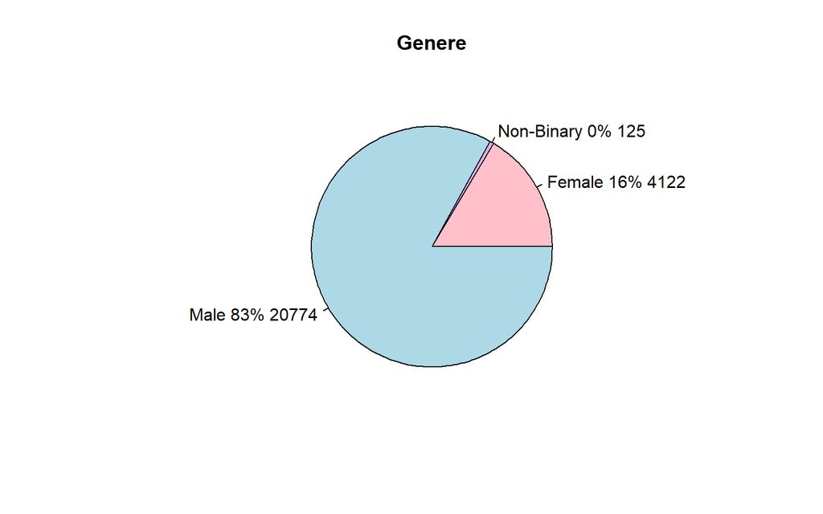

# DA DOVE PROVENGONO GLI SVILUPPATORI CHE HANNO RISPOSTO AL SONDAGGIO?

La maggiorparte degli intervistati sia uomini che donne proviene dall’India: L’India infatti è un paese dal punto di vista tecnologico molto all’avanguardia e che investe molto sullo sviluppo scientifico e informatico.

```
## 146 codes from your data successfully matched countries in the map
## 7 codes from your data failed to match with a country code in the map
## 99 codes from the map weren't represented in your data
```

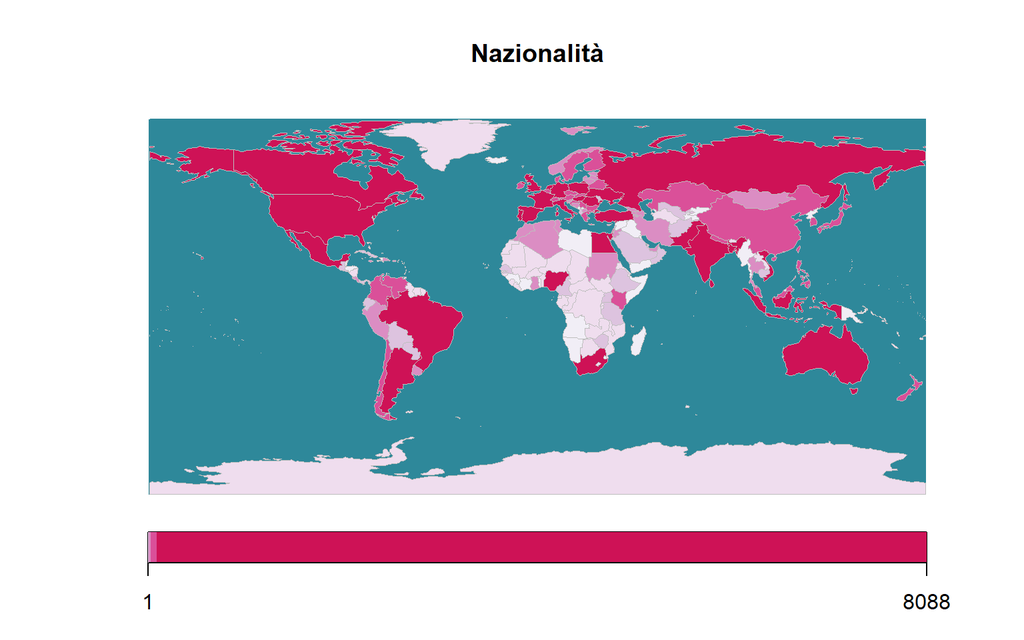

## Nazionalità Donne

[interactive chart not shown]

## Nazionalità Uomini

[interactive chart not shown]

# CHE ETA’ HANNO GLI SVILUPPATORI CHE HANNO RISPOSTO AL SONDAGGIO?

Vediamo che il picco (oltre 12000 persone) è nel range d’età tra i 18 e i 24 anni e a seguire vi è il range d’età tra 25-34 anni.

[interactive chart not shown]

# A CHE ETA’ HANNO INIZIATO A PROGRAMMARE?

Le donne che hanno iniziato a programmare presto (5-10 anni e 11-15 anni) sono pochissime rispetto agli uomini.

[interactive chart not shown]

# IN QUALE PAESE SI E’ INIZIATO A PROGRAMMARE PRIMA?

I Paesi in cu si è iniziato a programmare più presto sono gli Stati Uniti, l’India e il Regno Unito.

[interactive chart not shown]

# CHE PERCORSO DI ISTRUZIONE HANNO COMPIUTO UOMINI E DONNE PER ARRIVARE AL LORO STATO ATTUALE?

La perenutale di ragazzi che imparano da autodidatta è di molto maggiore rispetto a quella delle ragazze.

## Donne

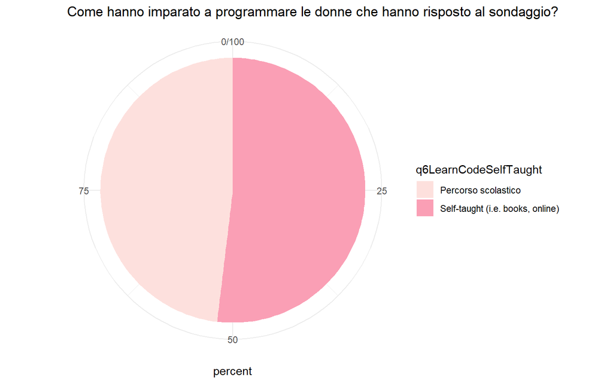

## Uomini

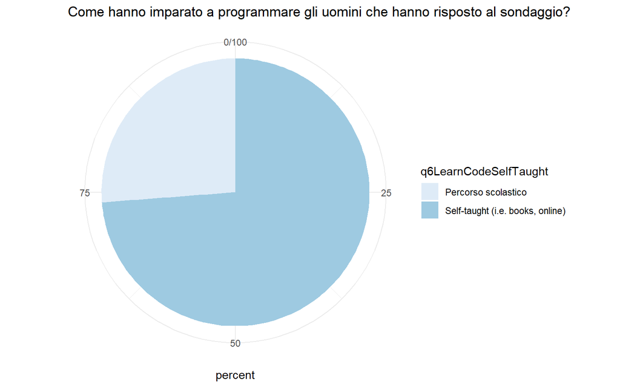

# IN CHE MODO HANNO STUDIATO PROGRAMMAZIONE (studenti Vs professionisti)?

La diffusione di Internet ha stravolto i tradizionali mezzi di apprendimento: Siti e risorse digitali hanno preso il posto dei libri cartacei.

## Donne:

[interactive chart not shown]

## Uomini:

[interactive chart not shown]

# QUALI PERCORSI UNIVERSITARI SONO STATI I PIU’ FREQUENTATI?

Per entrambi i generi i corsi più gettonati sono Computer Science e ingegneria informatica e a seguire Sistemi informatici. Per le donne vi è, inoltre, la tendenza verso lauree di tipo umanistico, mentre per gli uomini di tipo ingegneristico.

## Donne

[interactive chart not shown]

## Uomini

[interactive chart not shown]

# ATTUALMENTE CHE LAVORO STANNO SVOLGENDO?

I lavori più svolti sono: Software Engineering, Web Development, Software Architecture, Data Scientist, Data Analist, Network and Database Administrator…

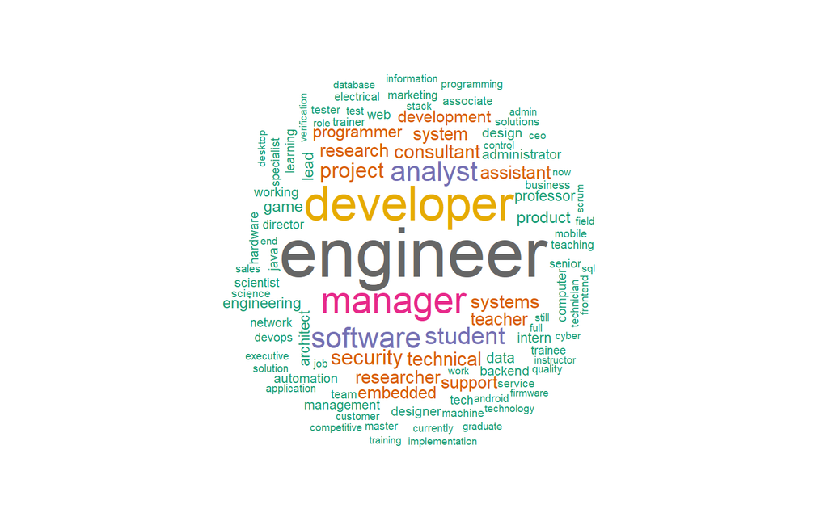

[interactive chart not shown]

# QUAL E’ IL LORO LIVELLO DI LAVORO?

Le donne hanno molta più probabilità di essere in posizioni junior rispetto agli sviluppatori uomini.

## Donne

[interactive chart not shown]

## Uomini

[interactive chart not shown]

# CAMPI IN EVOLUZIONE NELL INFORMATICA

Data science,Big Data, App/Web Development, Cyber security, Cloud Computing, Artificial Intelligence, Machine Learning, Robotics, Blockchain,

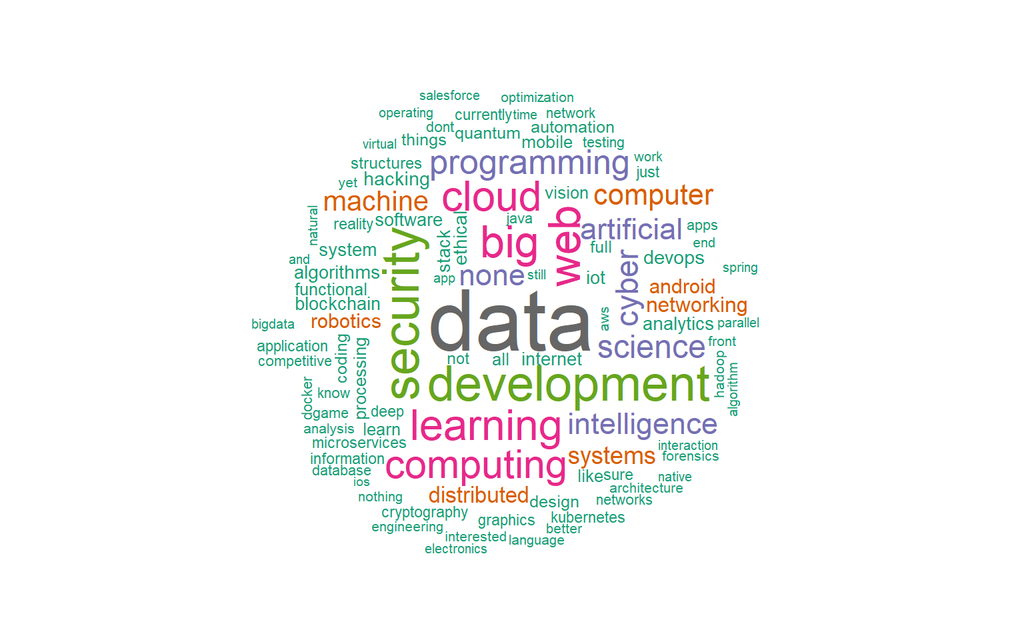

# A QUALI COMPETENZE PRESTANO PIU’ ATTENZIONE I RESPONSABILI DELLE ASSUNZIONI AL MOMENTO DELLA CANDIDATURA?

## Cosa guardano maggiormente i responsabili delle aziende in un curriculum:

Le esperienze lavorative pregresse e il percorso universitario sono fattori fondamental che influiscono sulla candidatura, tuttavia c’è anche un’altra cosa che interessa ai responsabili delle assunzioni: le pubblicazioni e i progetti personali.

[interactive chart not shown]

## Linguaggi di programmazione più richiesti dalle aziende:

Al giorno d’oggi Javascript e Java sono oramai diventate fondamentali per entrare nel mondo del lavoro.

[interactive chart not shown]

## Abilità più richieste dalle aziende:

Pe i responsabili delle assunzioni non sono importanti solo le competenze tecniche, ma anche capacità intrinseche come la capacità di risolvere i problemi e il debugging.

[interactive chart not shown]

# CONCLUSIONI

Per riepilogare, in questa analisi abbiamo riscontrato nella prima parte che:

- vi è una grande discrepanza in fatto di numerosità tra sviluppatrici donne e sviluppatori uomini
- le donne sono meno motivate dalla società a imparare a programmare in tenera età
- le donne hanno una maggiore probabilità rispetto agli uomini di rimanere sviluppatrici di primo livello (junior)

nella parte finale dell’analisi, invece, che:

- I campi in via di sviluppo in cui ci sarà una maggiore disponibilità lavorativa sono Data Science, Cyber Security, Web Development, Machine Learning e Artificial Intelligence
- Per entrare al meglio nel mondo del lavoro bisogna:
  - sviluppare capacità di problem solving e debugging
  - conoscere i linguaggi di programmazione più richiesti dalle aziende quali: Javascript, Java, python e C
  - sviluppare progetti personali e pubblicazioni